# Inferencia Bayesiana

## Settings

```r
rm(list = ls())
bomb_data <- read.csv("../data/geocoded_bomb_data.csv")

bomb_data$Time <- as.POSIXct(bomb_data$Time)

bomb_data$district <- as.factor(bomb_data$district)
bomb_data$Type.of.bomb <- as.factor(bomb_data$Type.of.bomb)

knitr::kable(head(bomb_data))
```

| X | Time | Location | Type.of.bomb | Damage.or.other | lat | lon | district |
| --- | --- | --- | --- | --- | --- | --- | --- |
| 1 | 1940-09-07 00:08:00 | 43 Southwark Park Road, SE16, London, UK | IB | Grocers: 3x2 roof damaged | 51.49225 | -0.0621761 | Southwark |
| 2 | 1940-09-07 00:10:00 | 49 Southwark Park road, Bermondsey, SE16, London, UK | IB | Bakers: 3x2 roof damaged | 51.49269 | -0.0653908 | Southwark |
| 3 | 1940-09-07 00:15:00 | 84 Southwark Park Road, SE16, London, UK | IB | front room on 1st floor and contents slightly damaged. 3x2 rood damage | 51.49225 | -0.0621761 | Southwark |
| 4 | 1940-09-07 00:18:00 | 141 Braidwood Road, Catford SE6, London, UK | IB | 10x6 roof damage | 51.44085 | -0.0053336 | Lewisham |
| 5 | 1940-09-07 00:20:00 | 129 Killearn Road, Catford SE6, London, UK | IB | Front room on 1st floor severely damaged | 51.44151 | -0.0054617 | Lewisham |
| 6 | 1940-09-07 00:20:00 | 27 Crutchley Road, Downham, London, UK | IB | IB on enclosed ground at rear of premises | 51.43674 | 0.0052611 | Lewisham |

```r
summary(bomb_data)
```

```
##        X              Time                           Location
##  Min.   :  1.0   Min.   :1940-09-07 00:08:00.000   Length:843
##  1st Qu.:211.5   1st Qu.:1940-09-07 18:00:00.000   Class :character
##  Median :422.0   Median :1940-09-07 18:28:00.000   Mode  :character
##  Mean   :422.0   Mean   :1940-09-07 18:08:30.253
##  3rd Qu.:632.5   3rd Qu.:1940-09-07 20:56:00.000
##  Max.   :843.0   Max.   :1940-09-07 23:59:00.000
##
##               Type.of.bomb Damage.or.other         lat
##  IB                 :478   Length:843         Min.   :50.72
##  EB                 :220   Class :character   1st Qu.:51.47
##  EB.and.IB          : 59   Mode  :character   Median :51.49
##  COB                : 10                      Mean   :51.50
##  Unknow.enemy.action:  6                      3rd Qu.:51.51
##  (Other)            :  3                      Max.   :55.16
##  NA's               : 67                      NA's   :8
##       lon                     district
##  Min.   :-3.52493   Tower Hamlets :192
##  1st Qu.:-0.08988   Lewisham      :139
##  Median :-0.04334   Southwark     :102
##  Mean   :-0.06730   City of London: 86
##  3rd Qu.:-0.01223   Greenwich     : 78
##  Max.   : 0.14640   (Other)       :218
##  NA's   :8          NA's          : 28
```

## Modelacion

### Variable aleatoria

Muestra antes de la 6:34 a.m.

```r
sample_EB <- as.numeric(bomb_data$Type.of.bomb == "EB")

sunrise_hour <- as.POSIXct("1940-9-7 06:34:00")

sample_before_sunrise <-
  sample_EB[bomb_data$Time <= sunrise_hour]

sample_before_sunrise <- na.omit(sample_before_sunrise)
n_before_sunrise <- length(sample_before_sunrise)
```

Definimos la siguiente variable aleatioria:
$$X =
\begin{cases}
1 & \text{si BOMBA EXPLOSIVA(EB)} \\
0 & \text{en otro cas}
\end{cases}$$

## Calculo de la aposteriori

### Funcion de verosimilitud

La variable $X$ es distribuida como una Bernoulli, tomando como muestra $X_1, \dots, X_n$, podemos definir la funcion de verosimilitud
$$L(p|\mathbb{X}) = \prod_{i=1}^{n}f(x_i|p) = p^{\sum_{i=1}^n
x_i}(1-p)^{n-\sum_{i=1}^n x_i}$$

### Calculo de la apriori

La apriori de Jeffrey se calcula como:
$$\pi(p) = \frac{1}{\sqrt{p(1-p)}} , \quad p \in (0,1)$$
Es decir que
$$p \sim Beta(\frac{1}{2}, \frac{1}{2})$$

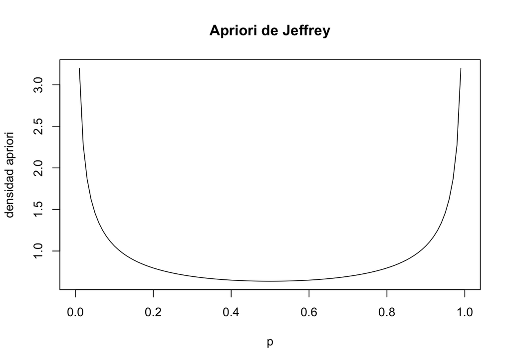

```r
curve(dbeta(x, shape1 = 1/2, shape2 = 1/2), xlab = "p", ylab = "densidad apriori")
title("Apriori de Jeffrey")
```

### Calculo de la aposteriori

Usando la apriori y la verosimilitud se puede calcular la distribucion aposteriori de p $$
$$\begin{align}
\pi(p|\mathbb{X}) &\propto L(p|\mathbb{X})\pi(p) \\
&\propto p^{\sum_{i=1}^n x_i - 1/2}(1-p)^{n-\sum_{i=1}^n x_i-1/2}
\end{align}$$
$$

Es decir que
$$p|\mathbb{X} \sim Beta(\sum_{i=1}^n x_i + 1/2, \quad n-\sum_{i=1}^n
x_i+1/2)$$

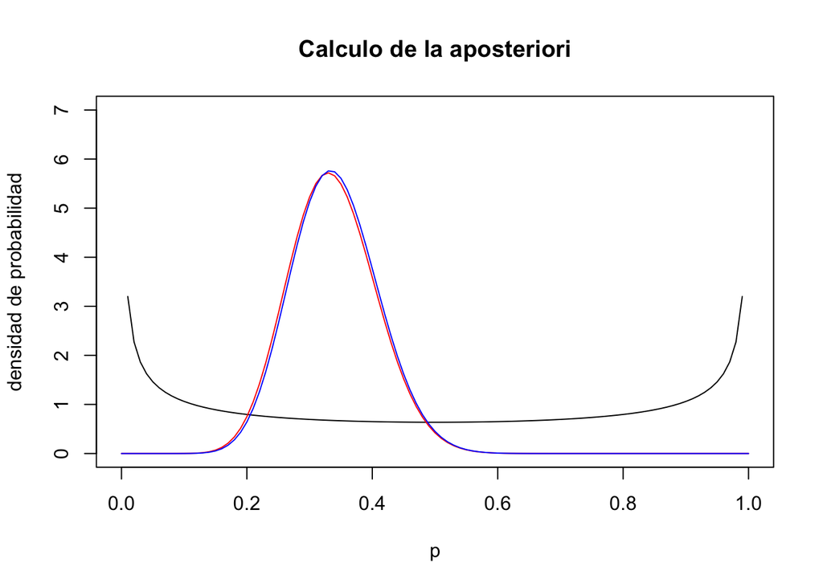

```r
# apriori
curve(dbeta(x, shape1 = 1/2, shape2 = 1/2),
      xlab = "p", ylab = "densidad de probabilidad",
      xlim = c(0,1), ylim = c(0,7))

# aposteriori
curve(dbeta(x,
             shape1 = sum(sample_before_sunrise) + 1/2,
             shape2 = n_before_sunrise - sum(sample_before_sunrise) + 1/2),
      add = T, col = "red")

# funcion de verosimilitud
curve(dbeta(x,
             shape1 = sum(sample_before_sunrise) + 1,
             shape2 = n_before_sunrise - sum(sample_before_sunrise) + 1),
      add = T, col = "blue")

title("Calculo de la aposteriori")
```

## Predicciones en la noche siguiente

Muestra despues del anochecimiento

```r
sunset_hour <- as.POSIXct("1940-9-7 19:16:00")

sample_after_sunset <-
  sample_EB[bomb_data$Time >= sunset_hour]

sample_after_sunset <- na.omit(sample_after_sunset)
n_after_sunset <- length(sample_after_sunset)
```

### Estimador de Bayes

Media de la distribucion aposteriori (considerando funcion de perdida cuadratica)

```r
estimador_bayes <-
  (sum(sample_before_sunrise) + 1/2)/(sum(sample_before_sunrise) + 1/2 + n_before_sunrise - sum(sample_before_sunrise) + 1/2)

estimador_bayes
```

```
## [1] 0.3369565
```

### Intervalo de Credibilidad

```r
library(HDInterval)

hdi(qbeta(c(0.05, 0.95),
          shape1 = sum(sample_before_sunrise) + 1/2,
          shape2 = n_before_sunrise - sum(sample_before_sunrise) + 1/2))
```

```
##     lower     upper
## 0.2276079 0.4544532
## attr(,"credMass")
## [1] 0.95
```

Valor observado despues del anochecimiento

```r
sum(sample_after_sunset)/n_after_sunset
```

```
## [1] 0.2898551
```

### Densidad predictiva

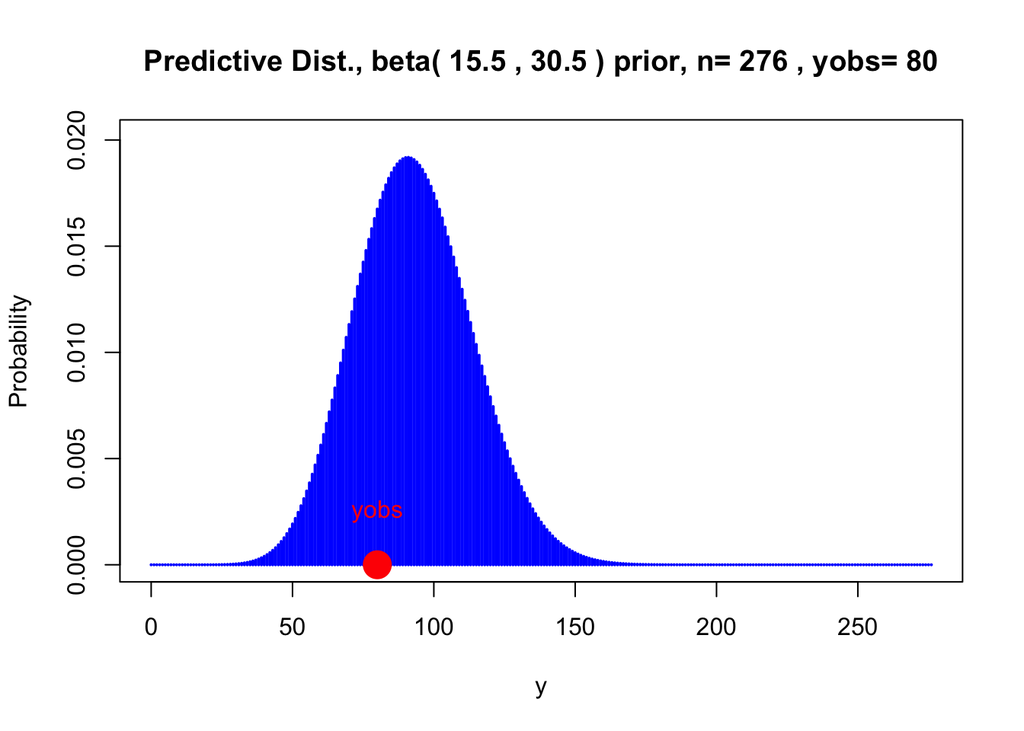

```r
library(LearnBayes)

prior_beta_params <- c(sum(sample_before_sunrise) + 1/2,
                       n_before_sunrise - sum(sample_before_sunrise) + 1/2)

# densidad predictiva
predictions <- pbetap(prior_beta_params, n_after_sunset, 0:n_after_sunset)

predplot(prior_beta_params, n_after_sunset, 80)
```

## Constraste de hipotesis sobre tipos de bombas en Greenwich

Como antes, usamos una apriori de Jeffrey, calculamos la aposteriori usando todos los datos del dia (primero dia del bombardeo)

Datos del dia (Greenwich district)

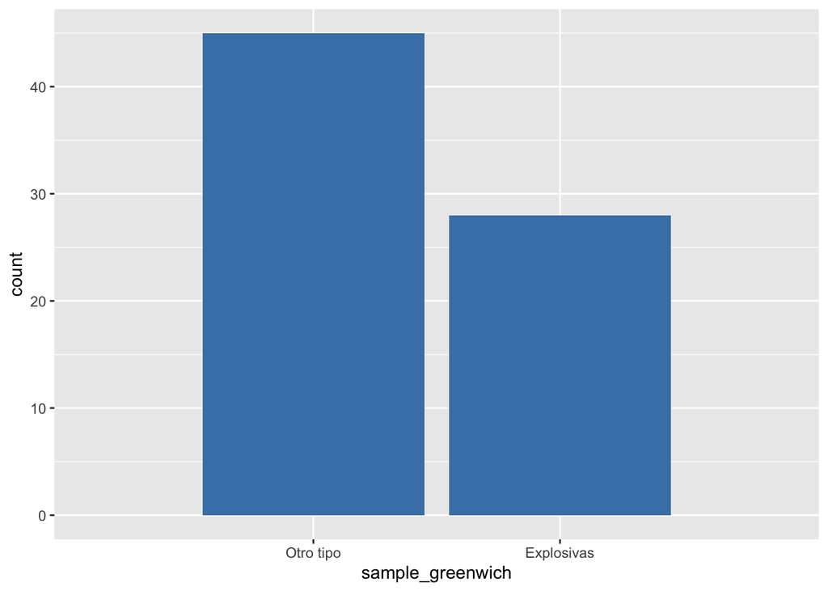

```r
sample_greenwich <- sample_EB[bomb_data$district == "Greenwich"]
sample_greenwich <- na.omit(sample_greenwich)

n_greenwich <- length(sample_greenwich)

#descriptive
library(ggplot2)
ggplot(mapping = aes(x = sample_greenwich)) +
  geom_bar(fill = "steelblue") +
  scale_x_discrete(limit = c(0,1), labels = c("Otro tipo", "Explosivas"))
```

Calculo de la aposteriori

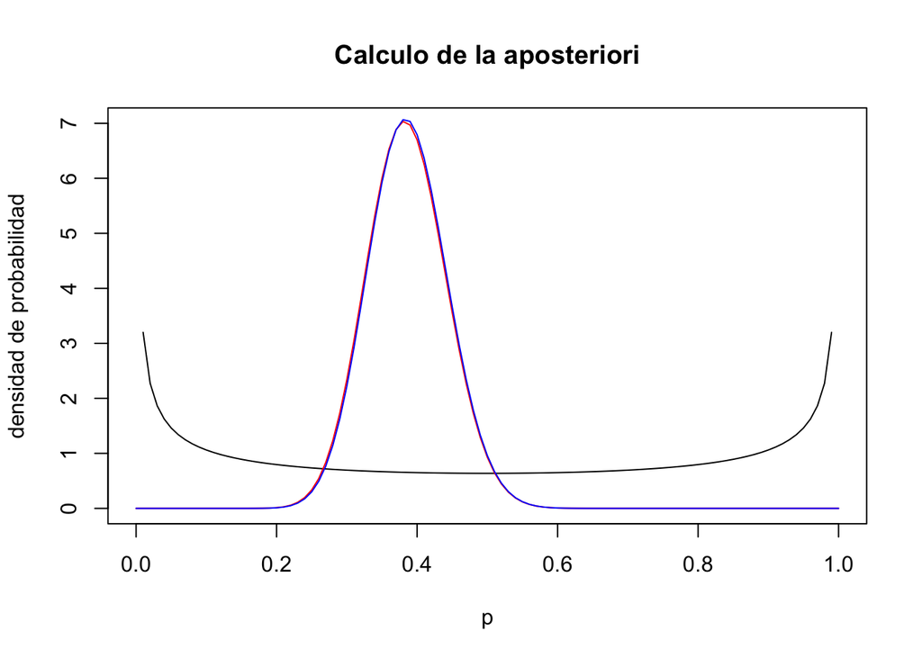

```r
# apriori
curve(dbeta(x, shape1 = 1/2, shape2 = 1/2),
      xlab = "p", ylab = "densidad de probabilidad",
      xlim = c(0,1), ylim = c(0,7))

# aposteriori
curve(dbeta(x,
             shape1 = sum(sample_greenwich) + 1/2,
             shape2 = n_greenwich - sum(sample_greenwich) + 1/2),
      add = T, col = "red")

# funcion de verosimilitud
curve(dbeta(x,
             shape1 = sum(sample_greenwich) + 1,
             shape2 = n_greenwich - sum(sample_greenwich) + 1),
      add = T, col = "blue")

title("Calculo de la aposteriori")
```

Contraste de hipotesis $$
$$\begin{align}
H_0: p > 0.5 \\
H_1: p \leq 0.5
\end{align}$$
$$ Calculo del Factor de Bayes

```r
# posteriors
posterior_H1 <- pbeta(0.5, sum(sample_greenwich) + 1/2, n_greenwich - sum(sample_greenwich) + 1/2)
posterior_H0 <- 1 - pbeta(0.5, sum(sample_greenwich) + 1/2, n_greenwich - sum(sample_greenwich) + 1/2)

# priors
prior_H1 <- pbeta(0.5, 1/2, 1/2)
prior_H0 <- 1 - pbeta(0.5, 1/2, 1/2)

# Factor de Bayes
FB01 <- (posterior_H0/posterior_H1)*(prior_H1/prior_H0)
FB01
```

```
## [1] 0.02347701
```